# Waffle charts of language speakers in Texas & their poverty levels

```r
library(tidyverse)
library(janitor)
library(waffle)
```

I want to create a waffle chart for language speakers in Texas, and looking at the share of people below & at or above poverty level.

Reading data

```r
above <- readRDS("data-out/above-1.rds")
below <- readRDS("data-out/below-1.rds")

#renaming column names
names(above) <- names(above) %>%
  str_replace_all("at_or_above_poverty_level_", "")

names(below) <- names(below) %>%
  str_replace_all("below_poverty_level_", "")

below
```

| year | total | moe_total | below_poverty_level | moe_below_poverty_level | only_english | moe_only_english | spanish | moe_spanish | other_indo_european_languages | moe_other_indo_european_languages | asian_and_pacific_island_languages | moe_asian_and_pacific_island_languages | other_languages | moe_other_languages |
| --- | --- | --- | --- | --- | --- | --- | --- | --- | --- | --- | --- | --- | --- | --- |
| 2010 | 22748636 | 6857 | 3864926 | 44825 | 1903850 | 33080 | 1794164 | 38517 | 63414 | 8136 | 73440 | 7213 | 30058 | 5261 |
| 2011 | 23140955 | 8434 | 4048290 | 54867 | 1996811 | 40884 | 1882565 | 40767 | 63254 | 8178 | 74235 | 7695 | 31425 | 5814 |
| 2012 | 23545402 | 6642 | 4014390 | 51195 | 1992232 | 33308 | 1847570 | 37277 | 59745 | 7008 | 77678 | 7466 | 37165 | 7843 |
| 2013 | 23935698 | 6740 | 4011520 | 56813 | 2032009 | 36739 | 1808405 | 38891 | 59572 | 6213 | 78789 | 7757 | 32745 | 5952 |
| 2014 | 24414846 | 7289 | 4011816 | 54014 | 1971229 | 36659 | 1848506 | 45280 | 65118 | 8106 | 79991 | 5833 | 46972 | 6949 |
| 2015 | 24902181 | 8028 | 3772329 | 58466 | 1880631 | 35217 | 1698690 | 46901 | 65866 | 6948 | 77687 | 6672 | 49455 | 9434 |
| 2016 | 25251359 | 7932 | 3778843 | 53952 | 1886163 | 35528 | 1692668 | 41339 | 67299 | 6974 | 88288 | 7755 | 44425 | 5719 |
| 2017 | 25682797 | 8203 | 3622315 | 55980 | 1851289 | 37387 | 1572092 | 39857 | 66539 | 6643 | 78574 | 7596 | 53821 | 8980 |

Let’s select for only the estimates and filter for only 2017

```r
above_2017 <- above %>%
  filter(year == 2017) %>%
  select(only_english, spanish, other_indo_european_languages, asian_and_pacific_island_languages, other_languages)

above_2017
```

| only_english | spanish | other_indo_european_languages | asian_and_pacific_island_languages | other_languages |
| --- | --- | --- | --- | --- |
| 14634618 | 6025474 | 524290 | 663474 | 212626 |

```r
below_2017 <- below %>%
  filter(year == 2017) %>%
  select(only_english, spanish, other_indo_european_languages, asian_and_pacific_island_languages, other_languages)

total_2017 <- bind_rows(
  "below" = below_2017,
  "above" = above_2017,
  .id = "poverty_status")

total_2017
```

| poverty_status | only_english | spanish | other_indo_european_languages | asian_and_pacific_island_languages | other_languages |
| --- | --- | --- | --- | --- | --- |
| below | 1851289 | 1572092 | 66539 | 78574 | 53821 |
| above | 14634618 | 6025474 | 524290 | 663474 | 212626 |

Let’s calculate sum of total language speakers (both below and above poverty)

```r
waffle_total_17 <- total_2017 %>%
  select_if(is.numeric) %>%
   map_dbl(sum)
```

Now let’s create a waffle chart!

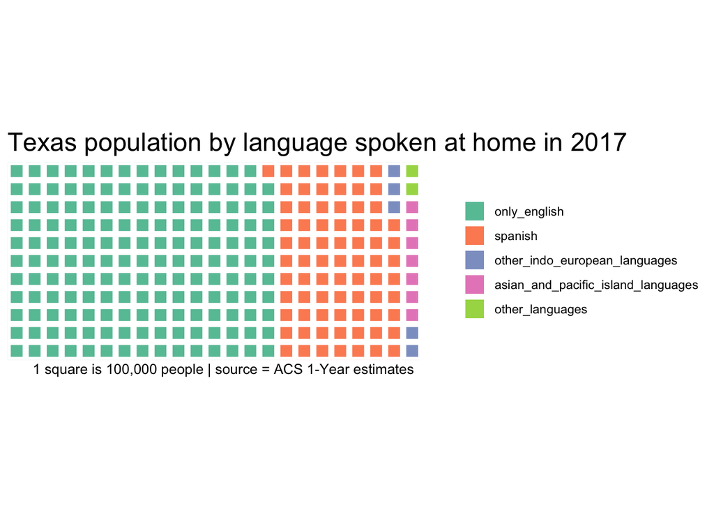

```r
waffle(waffle_total_17/100000, rows=11, title = "Texas population by language spoken at home in 2017", xlab = "1 square is 100,000 people | source = ACS 1-Year estimates")
```

Spanish speaking population are a big part of the whole Texas population. Population speaking a language other than English at home makes up a third of the population.

# Creating Waffle Chart for population above/below poverty, for all language groups.

first importing data from other notebook

```r
above_below <- readRDS("data-out/above_below_pct.rds")

above_below
```

| year | total | moe_total | at_or_above_poverty_level | moe_at_or_above_poverty_level | languages | estimate_above | moe_above | below_poverty_level | moe_below_poverty_level | estimate_below | moe_below | pct_below | pct_above |
| --- | --- | --- | --- | --- | --- | --- | --- | --- | --- | --- | --- | --- | --- |
| 2010 | 22748636 | 6857 | 18883710 | 45231 | only_english | 12870847 | 41094 | 3864926 | 44825 | 1903850 | 33080 | 12.88588 | 87.11412 |
| 2010 | 22748636 | 6857 | 18883710 | 45231 | spanish | 4975363 | 42642 | 3864926 | 44825 | 1794164 | 38517 | 26.50354 | 73.49646 |
| 2010 | 22748636 | 6857 | 18883710 | 45231 | other_indo_european_languages | 403663 | 16285 | 3864926 | 44825 | 63414 | 8136 | 13.57678 | 86.42322 |
| 2010 | 22748636 | 6857 | 18883710 | 45231 | asian_and_pacific_island_languages | 519484 | 15075 | 3864926 | 44825 | 73440 | 7213 | 12.38607 | 87.61393 |
| 2010 | 22748636 | 6857 | 18883710 | 45231 | other_languages | 114353 | 8731 | 3864926 | 44825 | 30058 | 5261 | 20.81420 | 79.18580 |
| 2011 | 23140955 | 8434 | 19092665 | 54542 | only_english | 13075340 | 48327 | 4048290 | 54867 | 1996811 | 40884 | 13.24835 | 86.75165 |
| 2011 | 23140955 | 8434 | 19092665 | 54542 | spanish | 4970865 | 46535 | 4048290 | 54867 | 1882565 | 40767 | 27.46895 | 72.53105 |
| 2011 | 23140955 | 8434 | 19092665 | 54542 | other_indo_european_languages | 410606 | 18010 | 4048290 | 54867 | 63254 | 8178 | 13.34867 | 86.65133 |
| 2011 | 23140955 | 8434 | 19092665 | 54542 | asian_and_pacific_island_languages | 515580 | 17315 | 4048290 | 54867 | 74235 | 7695 | 12.58615 | 87.41385 |
| 2011 | 23140955 | 8434 | 19092665 | 54542 | other_languages | 120274 | 11798 | 4048290 | 54867 | 31425 | 5814 | 20.71536 | 79.28464 |

[output cut: 30 more lines]

```r
above_below_waffle <- above_below %>%
  select (year, languages, pct_below, pct_above)

above_below_waffle_10 <- above_below_waffle %>%
  filter(year == 2010) #filter for 2010, because I only want to create waffle charts for 2017

above_below_waffle_10
```

| year | languages | pct_below | pct_above |
| --- | --- | --- | --- |
| 2010 | only_english | 12.88588 | 87.11412 |
| 2010 | spanish | 26.50354 | 73.49646 |
| 2010 | other_indo_european_languages | 13.57678 | 86.42322 |
| 2010 | asian_and_pacific_island_languages | 12.38607 | 87.61393 |
| 2010 | other_languages | 20.81420 | 79.18580 |

Now let’s create waffle charts

```r
above_below_waffle_gathered_10 <- above_below_waffle_10 %>%
  gather(key = "poverty_status", value="percentage", 3:4)

above_below_waffle_gathered_10
```

| year | languages | poverty_status | percentage |
| --- | --- | --- | --- |
| 2010 | only_english | pct_below | 12.88588 |
| 2010 | spanish | pct_below | 26.50354 |
| 2010 | other_indo_european_languages | pct_below | 13.57678 |
| 2010 | asian_and_pacific_island_languages | pct_below | 12.38607 |
| 2010 | other_languages | pct_below | 20.81420 |
| 2010 | only_english | pct_above | 87.11412 |
| 2010 | spanish | pct_above | 73.49646 |
| 2010 | other_indo_european_languages | pct_above | 86.42322 |
| 2010 | asian_and_pacific_island_languages | pct_above | 87.61393 |
| 2010 | other_languages | pct_above | 79.18580 |

```r
english_10 <- above_below_waffle_10 %>%
  mutate(year = NULL) %>%
  filter(languages == "only_english") %>%
  select(pct_above, pct_below)

spanish_10 <- above_below_waffle_10 %>%
  mutate(year = NULL) %>%
  filter(languages == "spanish") %>%
  select(pct_above, pct_below)


european_10 <- above_below_waffle_10 %>%
  mutate(year = NULL) %>%
  filter(languages == "other_indo_european_languages") %>%
  select(pct_above, pct_below)


asian_10 <- above_below_waffle_10 %>%
  mutate(year = NULL) %>%
  filter(languages == "asian_and_pacific_island_languages") %>%
  select(pct_above, pct_below)


other_10 <- above_below_waffle_10 %>%
  mutate(year = NULL) %>%
  filter(languages == "other_languages") %>%
  select(pct_above, pct_below)
```

creating multiple charts, combining with ggarange

```r
english_10
```

| pct_above | pct_below |
| --- | --- |
| 87.11412 | 12.88588 |

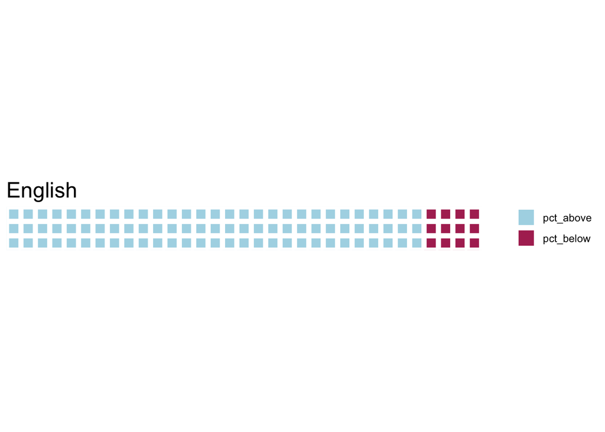

```r
english <- waffle(english_10, rows=3, title = "English", colors = c("light blue", "maroon", "white"))

english
```

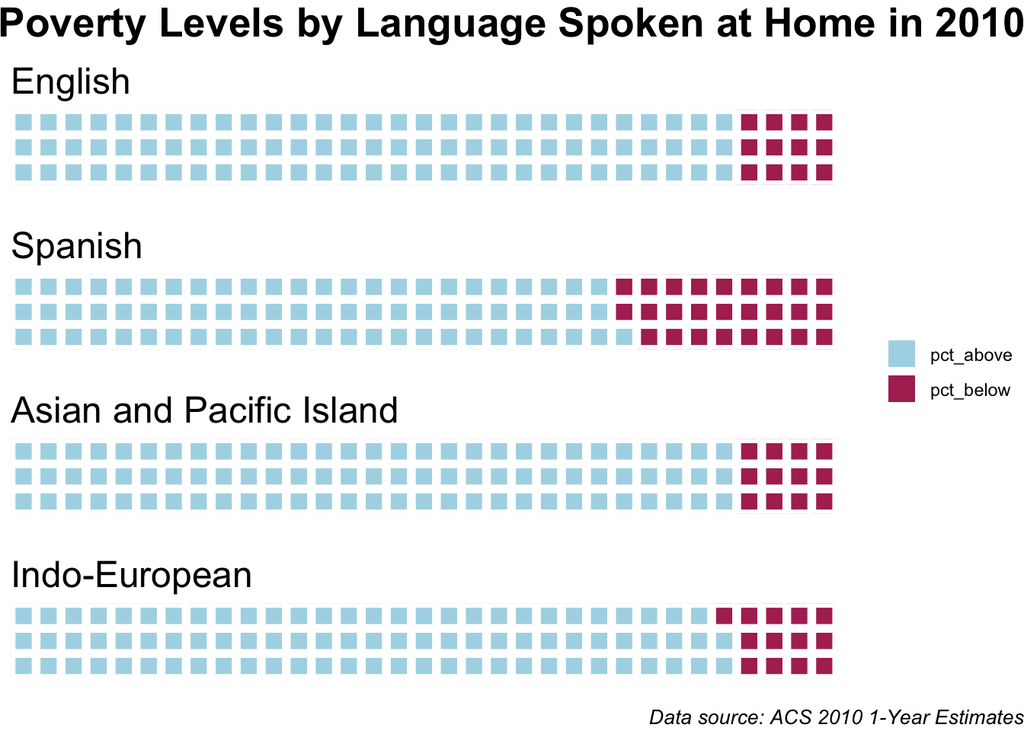

```r
spanish <- waffle(spanish_10, rows=3, title = "Spanish", colors = c("light blue", "maroon", "white"))

asian <- waffle(asian_10, rows=3, title = "Asian and Pacific Island",  colors = c("light blue", "maroon", "white"))

european <- waffle(european_10, rows=3, title = "Indo-European", colors = c("light blue", "maroon", "white"))

other <- waffle(other_10, rows=3, title = "Other", colors = c("light blue", "maroon", "white"))

library(ggpubr)
waffle_2010 <- ggarrange(english, spanish, asian, european, nrow = 4, common.legend = TRUE, legend ="right")

waffle_2010 %>% annotate_figure(top = text_grob("Poverty Levels by Language Spoken at Home in 2010", color = "black", face = "bold", size = 20),
               bottom = text_grob("Data source: ACS 2010 1-Year Estimates", color = "black",
                                  hjust = 1, x = 1, face = "italic", size = 10))
```

Now I can see the difference in percentage of population living above and below poverty. Spanish speakers have a higher share of people living in poverty.

Now let’s do it for 2017.

```r
above_below_waffle_17 <- above_below_waffle %>%
  filter(year == 2017) #filter for 2010, because I only want to create waffle charts for 2017
above_below_waffle_gathered_17 <- above_below_waffle_10 %>%
  gather(key = "poverty_status", value="percentage", 3:4)

english_17 <- above_below_waffle_17 %>%
  mutate(year = NULL) %>%
  filter(languages == "only_english") %>%
  select(pct_above, pct_below)

spanish_17 <- above_below_waffle_17 %>%
  mutate(year = NULL) %>%
  filter(languages == "spanish") %>%
  select(pct_above, pct_below)


european_17 <- above_below_waffle_17 %>%
  mutate(year = NULL) %>%
  filter(languages == "other_indo_european_languages") %>%
  select(pct_above, pct_below)


asian_17 <- above_below_waffle_17 %>%
  mutate(year = NULL) %>%
  filter(languages == "asian_and_pacific_island_languages") %>%
  select(pct_above, pct_below)


other_17 <- above_below_waffle_17 %>%
  mutate(year = NULL) %>%
  filter(languages == "other_languages") %>%
  select(pct_above, pct_below)
```

Creating multiple charts for 2017

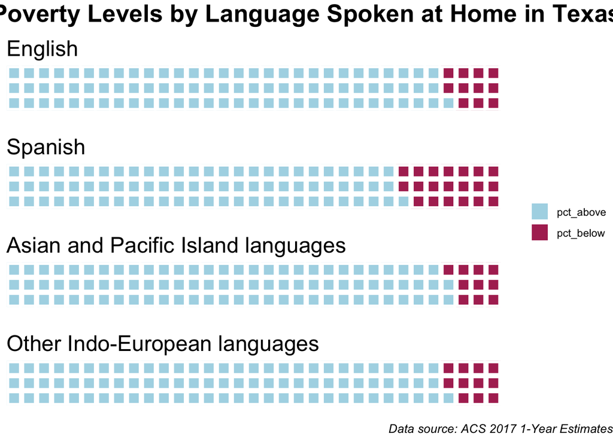

```r
english_2017 <- waffle(english_17, rows=3, title = "English", colors = c("light blue", "maroon", "white"))

spanish_2017 <- waffle(spanish_17, rows=3, title = "Spanish", colors = c("light blue", "maroon", "white"))

asian_2017 <- waffle(asian_17, rows=3, title = "Asian and Pacific Island languages",  colors = c("light blue", "maroon", "white"))

european_2017 <- waffle(european_17, rows=3, title = "Other Indo-European languages", colors = c("light blue", "maroon", "white"))

other_2017 <- waffle(other_17, rows=3, title = "Other", colors = c("light blue", "maroon", "white"))

library(ggpubr)
waffle_2017 <- ggarrange(english_2017, spanish_2017, asian_2017, european_2017, nrow = 4, common.legend = TRUE, legend ="right")

waffle_2017 %>% annotate_figure(top = text_grob("Poverty Levels by Language Spoken at Home in Texas", color = "black", face = "bold", size = 20),
               bottom = text_grob("Data source: ACS 2017 1-Year Estimates", color = "black",
                                  hjust = 1, x = 1, face = "italic", size = 10))
```

The gap is closer for 2017, compared with 2010.